# Quantitative variables

## Birth weights

```r
library(tidyverse)
d <- MASS::birthwt %>%
  mutate(race = factor(race, levels = 1:3, labels = c("white", "black", "other")),
         bw = factor(low, levels = c(1,0), labels = c("Low", "Normal")),
         smoke = factor(smoke, levels = c(1,0), labels = c("smoker", "non_smoker")),
         lwt_kg = 0.453592 * lwt)  # mother's weight: convert pounds to kg
head(d, 3)
```

```
   low age lwt  race      smoke ptl ht ui ftv  bwt     bw   lwt_kg
85   0  19 182 black non_smoker   0  0  1   0 2523 Normal 82.55374
86   0  33 155 other non_smoker   0  0  0   3 2551 Normal 70.30676
87   0  20 105 white     smoker   0  0  0   1 2557 Normal 47.62716
```

We want to compare the weight at birth (`bwt`) in smokers and non-smokers (independent distributions)

## Tests to compare two independent distributions

If distributions are about normal\(^1\): \(\quad\) Parametric tests

- If *homoscedastic*: \(\quad\) two-sample *t*-test (or unpaired *t*-test)
- If *heteroscedastic*: \(\quad\) Welch test (a *t*-test with Satterthwaite correction)

Otherwise: \(\quad\) Distribution-free (“non-parametric”) tests

- Wilcoxon rank sum test \(\quad \equiv \quad\) Mann-Whitney test

\(^1\) In practice, parametric tests work well if:  
- both distributions are (approximately) symmetrical, and  
- have no *influential* outliers

which can be inspected in a boxplot

## Boxplot (with means overlaid)

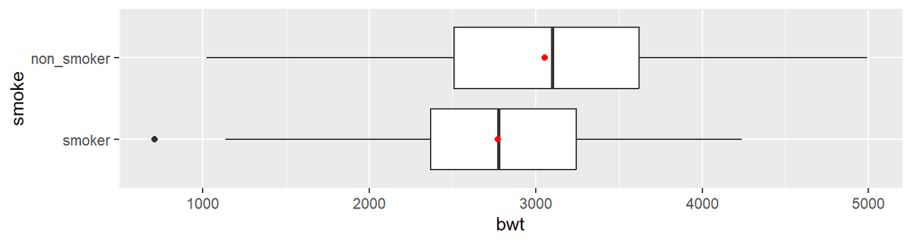

In this case:

- distributions are (approximately) symmetrical
- a single outlier in smokers, but not influential (mean = median)
- *heteroscedasticity* (different variances) ?

Parametric test is OK (Welch test, safer)

## Welch test (and CI for means difference)

Compares the group **means**, assuming *normal distribution* in both groups)

```r
t.test(bwt ~ smoke, data = d)                        # Welch test
```

```
    Welch Two Sample t-test

data:  bwt by smoke
t = -2.7299, df = 170.1, p-value = 0.007003
alternative hypothesis: true difference in means between group smoker and group non_smoker is not equal to 0
95 percent confidence interval:
 -488.97860  -78.57486
sample estimates:
    mean in group smoker mean in group non_smoker
                2771.919                 3055.696
```

## Unpaired *t*-test (and CI for difference of means)

Compares the group **means**, assuming *normal distribution* in both groups, and homoscedasticity.

```r
t.test(bwt ~ smoke, data = d, var.equal = TRUE)      # t-test
```

```
    Two Sample t-test

data:  bwt by smoke
t = -2.6529, df = 187, p-value = 0.008667
alternative hypothesis: true difference in means between group smoker and group non_smoker is not equal to 0
95 percent confidence interval:
 -494.79735  -72.75612
sample estimates:
    mean in group smoker mean in group non_smoker
                2771.919                 3055.696
```

## Why test equallity of **means**?

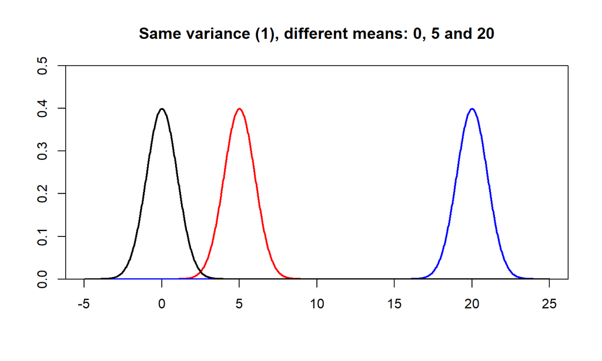

If two distributions are **normal** and have **equal variance**, then either:  
- they have different mean, or  
- they are identical

## Quantile-Quantile (QQ) plots, normal plots

In case you want to assess normality better than with a boxplot (not really needed), use this graphic

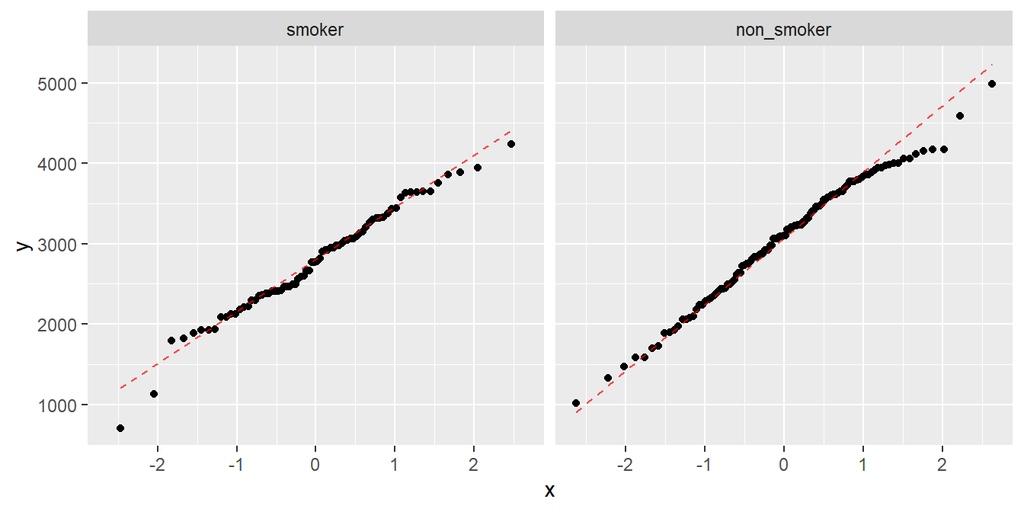

- normality tests (e.g., Shapiro-Wilks) is NOT advised:  
  normality can never be shown; rejection depends on power

## When conditions for Welch/*t*-test are not met

Suppose we want to compare the mother’s weight in smokers and non-smokers

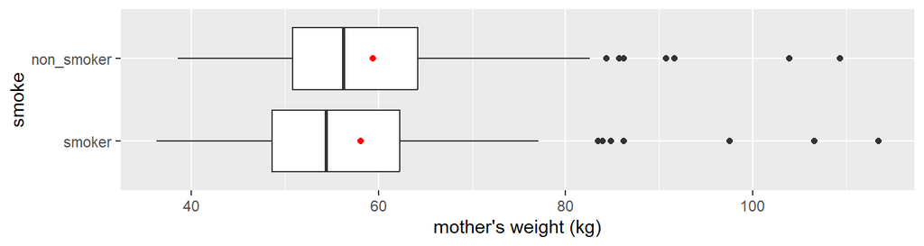

In this case:

- distributions are clearly assymmetrical
- influential outliers in both groups (mean shifted wrt median)

Distribution-free test (Wilcoxon RST)

## Wilcoxon rank sum test

```r
wilcox.test(lwt_kg ~ smoke, data = d)
```

```
    Wilcoxon rank sum test with continuity correction

data:  lwt_kg by smoke
W = 3826, p-value = 0.2427
alternative hypothesis: true location shift is not equal to 0
```

## Overlaying means in boxplots

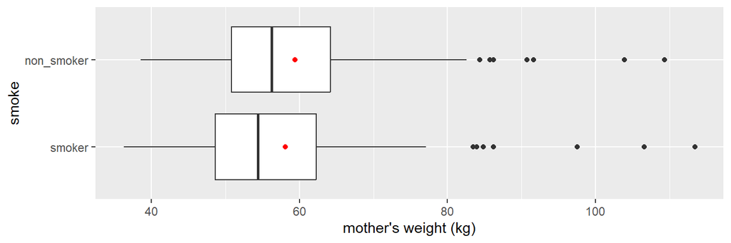

```r
library(ggformula)

gf_boxplot(lwt_kg ~ smoke, data = d, ylab = "mother's weight (kg)") %>%
  gf_summary(fun = mean, geom = "point", color = "red") %>%
  gf_refine(coord_flip())
```

## Exercise 1

Dataset `ais` in package `DAAG`: hematocrite (`hc`) and `sex` of 202 athletes.

```r
library(DAAG)
head(ais, 4)
```

```
   rcc wcc   hc   hg ferr   bmi   ssf pcBfat   lbm    ht   wt sex  sport
1 3.96 7.5 37.5 12.3   60 20.56 109.1  19.75 63.32 195.9 78.9   f B_Ball
2 4.41 8.3 38.2 12.7   68 20.67 102.8  21.30 58.55 189.7 74.4   f B_Ball
3 4.14 5.0 36.4 11.6   21 21.86 104.6  19.88 55.36 177.8 69.1   f B_Ball
4 4.11 5.3 37.3 12.6   69 21.88 126.4  23.66 57.18 185.0 74.9   f B_Ball
```

1. Is the hematocrite different in males and females? Inspect boxplots to decide if a parametric test is appropriate.
2. Give an estimate of the effect of sex on the hematocrite.
3. Would a distribution-free test produce a different result?

## Exercise 2

Download and read the `hta.xlsx` data following script, keeping only cases with at least one BP measurement and complete data for sex and total cholesterol:

```r
d <- rio::import("data/hta.xlsx") %>%
  filter(!is.na(sbp_v1)) %>%
  select(sex, total_c) %>%
  mutate(sex = factor(sex, 1:2, c("male", "female"))) %>%
  na.omit()
```

1. Is there any difference in total cholesterol levels of males and females?